# syde671_a1 (1)

```python
import cv2
import numpy as np

#file_path = "31421v.jpg"
#file_path = "10131v.jpg"
#file_path = "01598v.jpg"
file_path = "images/01164v.jpg"
image = cv2.imread(file_path)

image.shape
```

```
(1024, 396, 3)
```

Cropping is done in 3 steps:

First, remove the white outer border. This is done by simply taking the average brightness of each row in the image, then looking for the first row from the top that has a lower average brightness than a certain cutoff, and removing all rows above that one. The same is done from the bottom up (remove all rows below the first row from the bottom that is below the brightness cutoff), and from the left and right for the image's columns.

Next, a constant crop is done on each side of the image. This is done because the scan itself is not always exactly angled correctly, and thus the transition from white to black is often not perfectly horizontal. This leads to a few rows/columns between the white and black borders that are part-white and part-black, which can't be easily removed by using a naive method of taking the average brightness of a row/column.

Finally, step 1 is repeated for the inner black border, removing all rows/columns outside the first row/column that is above a certain brightness cutoff.

Cropping is done for the original image, then for each of the three component images to remove the black region in between images (in this case, the first step usually shouldn't crop anything).

Cropping for the white background seems to generally work well in my experience, but it works worse for the black region since there is often stains/writing/white spots on the black region, which causes problems for the naive average-brightness solution I'm using. I haven't seen any catastrophic failures, though, so I think it's good enough.

```python
def crop(image, white_cutoff, black_cutoff):
  img_height = len(image)
  img_width = len(image[0])

  # white background crop
  row_means = np.mean(image, axis=1)
  top = 0
  for row in range(img_height):
    avg_shade = row_means[row][0]
    if avg_shade < white_cutoff:
      break
    top += 1

  bottom = img_height
  for row in range(img_height - 1, -1, -1):
    avg_shade = row_means[row][0]
    if avg_shade < white_cutoff:
      break
    bottom -= 1

  image = image[top:bottom]

  col_means = np.mean(image, axis=0)

  left = 0
  for col in range(img_width):
    avg_shade = col_means[col][0]
    if avg_shade < white_cutoff:
      break
    left += 1

  right = img_width
  for col in range(img_width - 1, -1, -1):
    avg_shade = col_means[col][0]
    if avg_shade < white_cutoff:
      break
    right -= 1

  image = image[:, left:right]

  # extra crop to remove remaining white due to picture not being fully aligned
  extra_crop = img_height // 300

  image = image[extra_crop:-extra_crop, extra_crop:-extra_crop]

  # black background crop
  img_height = len(image)
  img_width = len(image[0])
  row_means = np.mean(image, axis=1)

  top = 0
  for row in range(img_height):
    avg_shade = row_means[row][0]
    if avg_shade > black_cutoff:
      break
    top += 1

  bottom = img_height
  for row in range(img_height - 1, -1, -1):
    avg_shade = row_means[row][0]
    if avg_shade > black_cutoff:
      break
    bottom -= 1

  image = image[top:bottom]

  col_means = np.mean(image, axis=0)

  left = 0
  for col in range(img_width):
    avg_shade = col_means[col][0]
    if avg_shade > black_cutoff:
      break
    left += 1

  right = img_width
  for col in range(img_width - 1, -1, -1):
    avg_shade = col_means[col][0]
    if avg_shade > black_cutoff:
      break
    right -= 1

  image = image[:, left:right]

  return image
```

Image contrast balance is done very simply, just take the maximum and minimum brightness value of all pixels in an image, and rescale all the pixel values by the formula $x = (x - \text{min}) * \frac{255}{\text{max} - \text{min}}$. This is done for each of the 3 color components of the image.

```python
def contrast_balance(image):
  image_max = np.max(image)
  image_min = np.min(image)
  scale = 255 / (image_max - image_min)
  offset = image_min
  image = (image - offset) * scale
  return image
```

```python
cropped_image = crop(image, 240, 50)
cv2.imwrite("cropped_image.jpg", cropped_image)

img_height = len(cropped_image)
img_width = len(cropped_image[0])

img_b = cropped_image[0:img_height//3]
img_g = cropped_image[img_height//3:-img_height//3]
img_r = cropped_image[-img_height//3:]
cv2.imwrite("img_b.jpg", img_b)
cv2.imwrite("img_g.jpg", img_g)
cv2.imwrite("img_r.jpg", img_r)
print(img_b.shape, img_g.shape, img_r.shape)

cropped_b = contrast_balance(np.max(crop(img_b, 240, 40), axis=2))
cropped_g = contrast_balance(np.max(crop(img_g, 240, 40), axis=2))
cropped_r = contrast_balance(np.max(crop(img_r, 240, 40), axis=2))
cv2.imwrite("cropped_b.jpg", cropped_b)
cv2.imwrite("cropped_g.jpg", cropped_g)
cv2.imwrite("cropped_r.jpg", cropped_r)
print(cropped_b.shape, cropped_g.shape, cropped_r.shape)
```

```
(331, 372, 3) (331, 372, 3) (331, 372, 3)
(329, 369) (329, 370) (329, 360)
```

I tried implementing both euclidean distance and normalized cross correlation. For both, the pattern I followed for transforming the second image is to pad it to the shape of the first image if it is shorter in the x or y axis, then apply the offset, then crop it to the size of the first image if it is larger in the x or y axis. (The first image is, in practice, always the blue channel of the image). There is a reason that I chose to do it this way (explained at the end of the page), but it ended up not mattering because of the next step (which I didn't consider doing until I read the tips section of the assignment):

```python
def euclidean_distance(image1, image2, x_offset, y_offset):
  image2 = np.pad(image2, ((0, max(0, image1.shape[0] - image2.shape[0])),
                           (0, max(0, image1.shape[1] - image2.shape[1]))))
  image2 = np.roll(image2, (x_offset, y_offset), axis=(1, 0))
  image2 = image2[:image1.shape[0], :image1.shape[1]]

  # remove border region
  border_crop_0 = image1.shape[0] // 20
  border_crop_1 = image1.shape[1] // 20
  image1 = image1[border_crop_0:-border_crop_0,border_crop_1:-border_crop_1]
  image2 = image2[border_crop_0:-border_crop_0,border_crop_1:-border_crop_1]

  # return negative sum since align function optimizes for highest score
  # (don't need to sqrt since we only care about optimization instead of
  #  actual distance)
  return -np.sum(abs(image1 - image2), dtype = np.float64)

def normalized_cross_correlation(image1, image2, x_offset, y_offset):
  image2 = np.pad(image2, ((0, max(0, image1.shape[0] - image2.shape[0])),
                           (0, max(0, image1.shape[1] - image2.shape[1]))))
  image2 = np.roll(image2, (x_offset, y_offset), axis=(1, 0))
  image2 = image2[:image1.shape[0], :image1.shape[1]]

  # remove border region
  border_crop_0 = image1.shape[0] // 10
  border_crop_1 = image1.shape[1] // 10
  image1 = image1[border_crop_0:-border_crop_0,border_crop_1:-border_crop_1]
  image2 = image2[border_crop_0:-border_crop_0,border_crop_1:-border_crop_1]

  # don't need image1 norm since we're only searching over possible offsets of
  # image2 (so image1 norm is constant)
  image2_norm = np.linalg.norm(image2)

  return np.sum(np.multiply(image1, image2, dtype=np.float64)) / image2_norm
```

I designed a wrapper function to combine the BGR images using any align function (either single scale or multi scale, and using any arbirtrary scoring function). An optimal offset is calculated for the green and red images, and layered onto the original blue image.

Note that the final image has color channels B, G, R. On Google Colab, this displays incorrectly (it expects the order to be R, G, B), but this is the correct order for the `cv2.imwrite` function, for some reason.

```python
def combine(image_b, image_g, image_r, align, output_file):
  offset_g, metric_g = align(image_b, image_g)
  offset_r, metric_r = align(image_b, image_r)

  print("Offset for green:", offset_g)
  print("Offset for red:", offset_r)

  image_g = np.pad(image_g, ((0, max(0, image_b.shape[0] - image_g.shape[0])),
                             (0, max(0, image_b.shape[1] - image_g.shape[1]))))
  image_g = np.roll(image_g, offset_g, axis=(1, 0))
  image_g = image_g[:image_b.shape[0], :image_b.shape[1]]

  image_r = np.pad(image_r, ((0, max(0, image_b.shape[0] - image_r.shape[0])),
                             (0, max(0, image_b.shape[1] - image_r.shape[1]))))
  image_r = np.roll(image_r, offset_r, axis=(1, 0))
  image_r = image_r[:image_b.shape[0], :image_b.shape[1]]

  final_image = np.stack([np.round(image_b), np.round(image_g), np.round(image_r)], axis=-1).astype(np.uint8)
  cv2.imwrite(output_file, final_image)
  return final_image
```

Single scale align function is relatively straightforward, it takes two images, a metric/scoring function, and a range of offsets to search.

```python
def single_scale_align(image1, image2, range_x, range_y, metric):
  best_metric = -float("inf")
  best_offset = (0,0)
  for x_offset in range_x:
    for y_offset in range_y:
      result = metric(image1, image2, x_offset, y_offset)
      if result > best_metric:
        best_metric = result
        best_offset = (x_offset, y_offset)
  return best_offset, best_metric
```

The euclidean distance function works fine for most images, but sometimes is very significantly off. I found the normalized cross correlation metric to more consistently produce good alignment.

```
((1, -4), np.float64(-2279536.0714285714))
((12, -9), np.float64(-4352427.817460318))
((1, -4), np.float64(48103.18065689028))
((12, -9), np.float64(47385.683633054054))
Offset for green: (1, -4)
Offset for red: (12, -9)
```

```
ndarray (329, 369, 3)
```

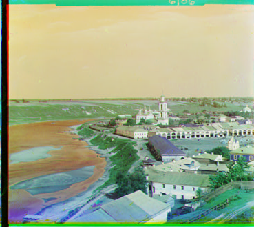

[output not shown]

```python
print(single_scale_align(cropped_b, cropped_g, range(-15,16), range(-15,16), euclidean_distance))
print(single_scale_align(cropped_b, cropped_r, range(-15,16), range(-15,16), euclidean_distance))

print(single_scale_align(cropped_b, cropped_g, range(-15,16), range(-15,16), normalized_cross_correlation))
print(single_scale_align(cropped_b, cropped_r, range(-15,16), range(-15,16), normalized_cross_correlation))

ss_align_w_params = lambda a,b: single_scale_align(a, b, range(-15,16), range(-15,16), normalized_cross_correlation)
combine(cropped_b, cropped_g, cropped_r, ss_align_w_params, "combined.jpg")
```

For multi scale alignment, I made a function that accepts an initial x and y range for the smallest scale image, and a number of scales that determines the height of the image pyramid.

Downsampling is simply done by taking only every $2^n$-th row and $2^n$-th column at scale $n$ (with scale $0$ being the full original image).

The choice to search a 5x5 area is an arbitrary choice that I found gave the best tradeoff between runtime and accuracy. When I searched smaller areas on each scale (e.g. 2x2, 3x3) I often found that the algorithm missed the best alignment.

```python
def multi_scale_align(image1, image2, range_x, range_y, num_scales, metric):
  image1_downsample = image1[::2**(num_scales-1), ::2**(num_scales-1)]
  image2_downsample = image2[::2**(num_scales-1), ::2**(num_scales-1)]
  best_metric = -float("inf")
  best_x = -1
  best_y = -1
  for x_offset in range_x:
    for y_offset in range_y:
      result = metric(image1_downsample, image2_downsample, x_offset, y_offset)
      if result > best_metric:
        best_metric = result
        best_x = x_offset
        best_y = y_offset
  for scale in range(num_scales-2, -1, -1):
    best_x *= 2
    best_y *= 2
    image1_downsample = image1[::2**scale, ::2**scale]
    image2_downsample = image2[::2**scale, ::2**scale]
    best_metric = -float("inf")
    for x_offset in range(best_x - 2, best_x + 3):
      for y_offset in range(best_y - 2, best_y + 3):
        result = metric(image1_downsample, image2_downsample, x_offset, y_offset)
        if result > best_metric:
          best_metric = result
          best_x = x_offset
          best_y = y_offset

  return (best_x, best_y), best_metric
```

```
((1, -4), np.float64(-2279536.0714285714))
((12, -9), np.float64(-4352427.817460318))
((1, -4), np.float64(48103.18065689028))
((12, -9), np.float64(47385.683633054054))
Offset for green: (1, -4)
Offset for red: (12, -9)
```

```
ndarray (329, 369, 3)
```

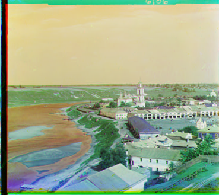

[output not shown]

```python
print(multi_scale_align(cropped_b, cropped_g, range(-3,4), range(-3,4), 5, euclidean_distance))
print(multi_scale_align(cropped_b, cropped_r, range(-3,4), range(-3,4), 5, euclidean_distance))
print(multi_scale_align(cropped_b, cropped_g, range(-3,4), range(-3,4), 3, normalized_cross_correlation))
print(multi_scale_align(cropped_b, cropped_r, range(-3,4), range(-3,4), 3, normalized_cross_correlation))

ms_align_w_params = lambda a,b: multi_scale_align(a, b, range(-3,4), range(-3,4), 3, normalized_cross_correlation)
combine(cropped_b, cropped_g, cropped_r, ms_align_w_params, "combined.jpg")
```

I decided the number of scales for each image using the formula $\text{num_scales} = \lfloor \log_2(\text{image width}) - 5\rfloor$, so that the smallest scale image will be relatively constant for any scale of image. The constant 5 is arbitrary, and was selected because it worked best for the dataset in practice.

```python
def full_pipeline(image, output_file):
  cropped_image = crop(image, 240, 50)

  img_height = len(cropped_image)
  img_width = len(cropped_image[0 ])

  img_b = cropped_image[0:img_height//3]
  img_g = cropped_image[img_height//3:-img_height//3]
  img_r = cropped_image[-img_height//3:]

  cropped_b = contrast_balance(np.max(crop(img_b, 240, 40), axis=2))
  cropped_g = contrast_balance(np.max(crop(img_g, 240, 40), axis=2))
  cropped_r = contrast_balance(np.max(crop(img_r, 240, 40), axis=2))

  num_scales = int(np.log2(img_width) - 5)

  ms_align_w_params = lambda a,b: multi_scale_align(a, b, range(-3,4), range(-3,4), num_scales, normalized_cross_correlation)
  return combine(cropped_b, cropped_g, cropped_r, ms_align_w_params, output_file)

import os

for file_path in os.listdir("images"):
  if file_path == ".ipynb_checkpoints":
    continue
  print(file_path)
  image = cv2.imread("images/" + file_path)
  full_pipeline(image, file_path + "_combined.jpg")
```

```
10131v.jpg
Offset for green: (1, -6)
Offset for red: (2, -11)
01007a.jpg
Offset for green: (12, -32)
Offset for red: (-38, -55)
31421v.jpg
Offset for green: (0, -4)
Offset for red: (0, -2)
00163v.jpg
Offset for green: (1, -8)
Offset for red: (1, -5)
00056v.jpg
Offset for green: (1, -5)
Offset for red: (1, -9)
01522v.jpg
Offset for green: (2, -5)
Offset for red: (1, -9)
my_image_2.jpg
Offset for green: (-2, -3)
Offset for red: (-3, -3)
01597v.jpg
Offset for green: (1, -7)
Offset for red: (2, -11)
00125v.jpg
Offset for green: (2, -3)
Offset for red: (1, -9)
01861a.jpg
Offset for green: (38, -26)
Offset for red: (50, -45)
01728v.jpg
Offset for green: (1, -4)
Offset for red: (1, -6)
01725u.jpg
Offset for green: (22, -55)
Offset for red: (49, -101)
01164v.jpg
Offset for green: (1, -4)
Offset for red: (12, -9)
01047u.jpg
```

[output cut: 8 more lines]

```
my_image_1.jpg
Offset for green: (2, -4)
Offset for red: (3, -6)
00804v.jpg
Offset for green: (-2, -6)
Offset for red: (-1, -11)
my_image_3.jpg
Offset for green: (-1, 0)
Offset for red: (-1, -4)
01269v.jpg
Offset for green: (2, -4)
Offset for red: (3, -6)
01657u.jpg
Offset for green: (12, -34)
Offset for red: (-19, -60)
```

*Note on the way that image2 is manipulated in the euclidean distance and normalized cross correlation function:

I did it this way because I wanted to somewhat mitigate spurious "matches" matching the right/bottom parts of the second image to the left/top of the first image. Doing it this way makes it so that if the second image is smaller than the first image, then more of the columns/rows rolled over to the other side will be padding columns/rows (which are all black). This doesn't fully solve the problem, as when image2 is larger than/equal size to image1 there is still the possibility of these spurious "matches", and even when it is smaller, a big enough offset will still cause this issue. Since the edges of both images are cropped out afterwards, though, none of this ends up mattering.